# homework1

2024-07-23

## Question 1:

1. Reproducibility = recompute data results on dataset with knowledge of the statistical pipeline used to calculate them
2. Replicability = chance that a new experiment targeting same scientific question will produce a consistent result
3. Susie & Joe share data. why can the study be reproducible but not replicable
   1. only sharing data doesn’t share the statistical pipeline

Initial answer was wrong so process of elimination

- **The code and data are available so the study is always replicable if it is reproducible.**
  - no
- **Joe doesn’t make the raw data accessible so Susan can’t re-run his code.**
  - i mean, he does, it says in the question
- **Susan only uses Python and Joe uses R so when she runs a new experiment, she will definitely get different results.**
  - as long as methods are the same, this shouldn’t matter
- **All the data and code are available but the codebook does not fully explain the experimental design and all protocols for patient recruitment.**
  - this makes enough sense

## Question 2:

Put the following code chunk at the top of an R markdown document called *test.Rmd* but set eval=TRUE

- The plot and table are random the first time you knit the document. They are identical the second time you knit the document. After removing the folders test_cache test_cache and test_files test_files they generate new random versions.

```r
knitr::opts_chunk$set(cache=TRUE)
```

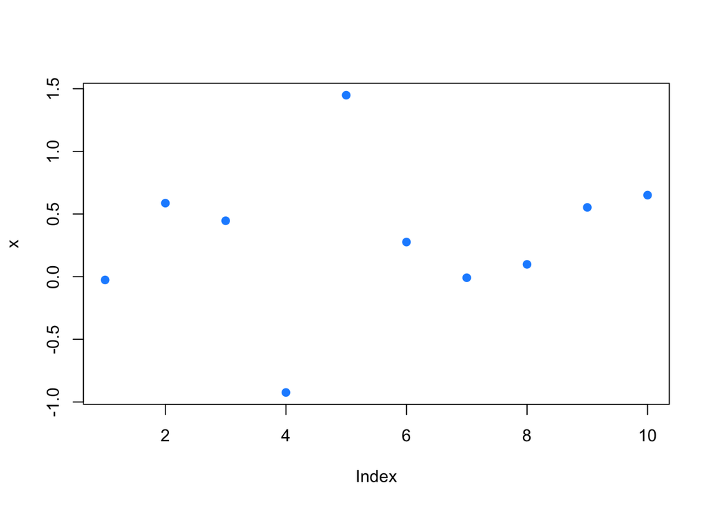

```r
x = rnorm(10)
plot(x,pch=19,col="dodgerblue")
```

```r
y = rbinom(20,size=1,prob=0.5)
table(y)
```

```
## y
##  0  1
## 10 10
```

## Question 3:

How do you access the genomic data for this object?

assay()

How do you access the phenotype table?

colData()

feature data

rowData()

what does rowRanges() do

gives information on the genomic location and structure of the measured features.

```r
# load the following code

library(Biobase)
library(GenomicRanges)
library(SummarizedExperiment)
data(sample.ExpressionSet, package = "Biobase")
se = makeSummarizedExperimentFromExpressionSet(sample.ExpressionSet)

class(se) # SummarizedExperiment object
```

```
## [1] "RangedSummarizedExperiment"
## attr(,"package")
## [1] "SummarizedExperiment"
```

```r
?SummarizedExperiment

?assay

assay(se)
```

[output not shown]

[output cut: 3452 more lines]

[output not shown]

```r
colData(se)
```

```
## DataFrame with 26 rows and 3 columns
##          sex     type     score
##     <factor> <factor> <numeric>
## A     Female  Control      0.75
## B     Male    Case         0.40
## C     Male    Control      0.73
## D     Male    Case         0.42
## E     Female  Case         0.93
## ...      ...      ...       ...
## V     Female  Control      0.77
## W     Male    Control      0.27
## X     Male    Control      0.98
## Y     Female  Case         0.94
## Z     Female  Case         0.32
```

```r
rowRanges(se)
```

```
## GRangesList object of length 500:
## $`AFFX-MurIL2_at`
## GRanges object with 0 ranges and 0 metadata columns:
##    seqnames    ranges strand
##       <Rle> <IRanges>  <Rle>
##   -------
##   seqinfo: no sequences
##
## $`AFFX-MurIL10_at`
## GRanges object with 0 ranges and 0 metadata columns:
##    seqnames    ranges strand
##       <Rle> <IRanges>  <Rle>
##   -------
##   seqinfo: no sequences
##
## $`AFFX-MurIL4_at`
## GRanges object with 0 ranges and 0 metadata columns:
##    seqnames    ranges strand
##       <Rle> <IRanges>  <Rle>
##   -------
##   seqinfo: no sequences
##
## ...
## <497 more elements>
```

## Question 4:

Suppose that you have measured ChIP-Seq data from 10 healthy individuals and 10 metastatic cancer patients. For each individual you split the sample into two identical sub-samples and perform the ChIP-Seq experiment on each sub-sample. How can you measure (a) biological variability, (b) technical variability and (c) phenotype variability.

1. biological variability = take multiple samples from both the healthy and cancer groups and compare within those groups to quantify the variability within each group
2. technical variability = take multiple samples and make subsamples from each group to preprocess twice to measure the variance introduced by the machine
3. phenotype variability = compare across cancer / normal

## Question 5:

Gonna say it’s this: The Bodymap data has measured more levels of the outcome of interest (tissues) than the Bottomly data has measured (strains).

- because there are so few observations for each tissue type
- turned out to be a wrong answer: I think the correct was about num of covariates

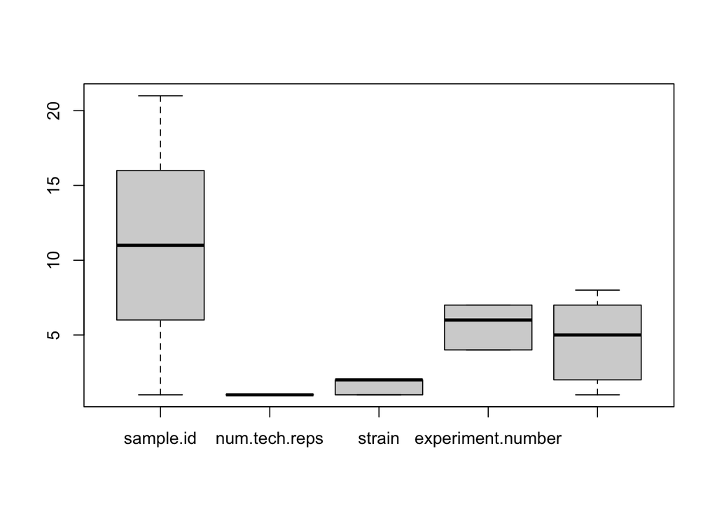

```r
# compare strains
con =url("http://bowtie-bio.sourceforge.net/recount/ExpressionSets/bottomly_eset.RData")
load(file=con)
close(con)
bot = bottomly.eset
pdata_bot=pData(bot)

# compare tissues
con =url("http://bowtie-bio.sourceforge.net/recount/ExpressionSets/bodymap_eset.RData")
load(file=con)
close(con)
bm = bodymap.eset
pdata_bm=pData(bm)

# smaller variance, higher power

boxplot(pdata_bot)
```

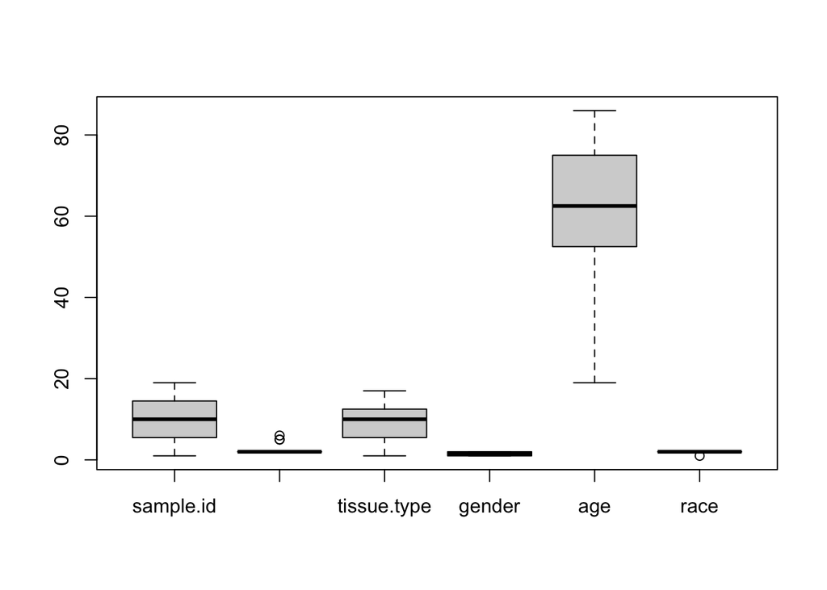

```r
boxplot(pdata_bm)
```

```r
length(pdata_bot)
```

```
## [1] 5
```

```r
length(pdata_bm)
```

```
## [1] 6
```

```r
pdata_bot$num.tech.reps
```

```
##  [1] 1 1 1 1 1 1 1 1 1 1 1 1 1 1 1 1 1 1 1 1 1
```

```r
pdata_bm$num.tech.reps
```

```
##  [1] 2 2 2 2 2 2 2 2 2 2 6 5 5 2 2 2 2 2 2
```

## Question 6:

The plot is in 3-d so it makes it hard to compare the angles.

## Question 7:

Which of the following code chunks will make a heatmap of the 500 most highly expressed genes (as defined by total count), without re-ordering due to clustering? Are the highly expressed samples next to each other in sample order?

- was an incorrect answer but dont know why
- other option that could’ve been right was (1) so i reselcted that

```r
con =url("http://bowtie-bio.sourceforge.net/recount/ExpressionSets/bodymap_eset.RData")
load(file=con)
close(con)
bm = bodymap.eset
edata = exprs(bm)

colnames(edata)
```

```
##  [1] "ERS025098" "ERS025092" "ERS025085" "ERS025088" "ERS025089" "ERS025082"
##  [7] "ERS025081" "ERS025096" "ERS025099" "ERS025086" "ERS025084" "ERS025087"
## [13] "ERS025093" "ERS025083" "ERS025095" "ERS025097" "ERS025094" "ERS025090"
## [19] "ERS025091"
```

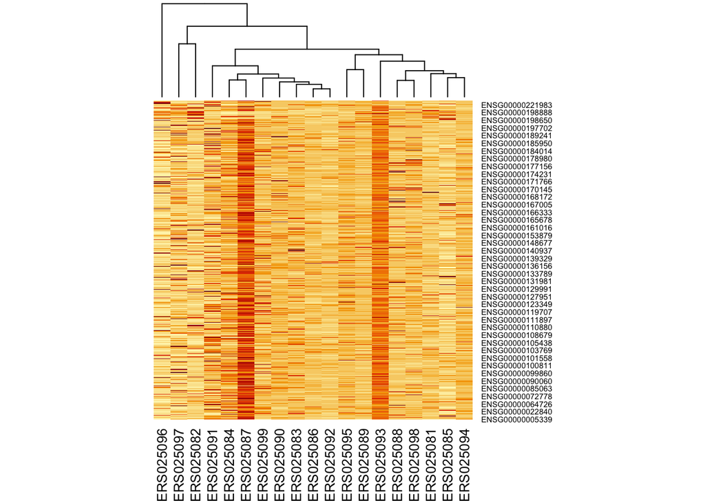

```r
row_sums = rowSums(edata)
index = which(rank(-row_sums) < 500 )
heatmap(edata[index,],Rowv=NA)
```

## Question 8:

Make an MA-plot of the first sample versus the second sample using the log2 transform (hint: you may have to add 1 first) and the rlog transform from the DESeq2 package. How are the two MA-plots different? Which kind of genes appear most different in each plot?

```r
con =url("http://bowtie-bio.sourceforge.net/recount/ExpressionSets/bodymap_eset.RData")
load(file=con)
ls()
```

```
##  [1] "bm"                   "bodymap.eset"         "bot"
##  [4] "bottomly.eset"        "con"                  "edata"
##  [7] "index"                "pdata_bm"             "pdata_bot"
## [10] "row_sums"             "sample.ExpressionSet" "se"
## [13] "x"                    "y"
```

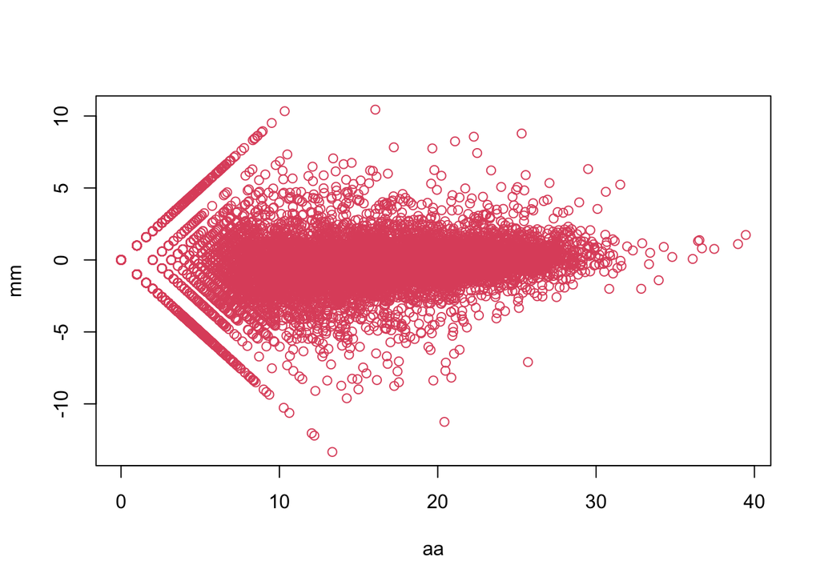

```r
close(con)
bm = bodymap.eset
pdata = pData(bm)
edata = exprs(bm)

library(DESeq2)

# log2
mm = log2(edata[,1]+1) - log2(edata[,2]+1)
aa = log2(edata[,1]+1) + log2(edata[,2]+1)
plot(aa, mm, col = 2)
```

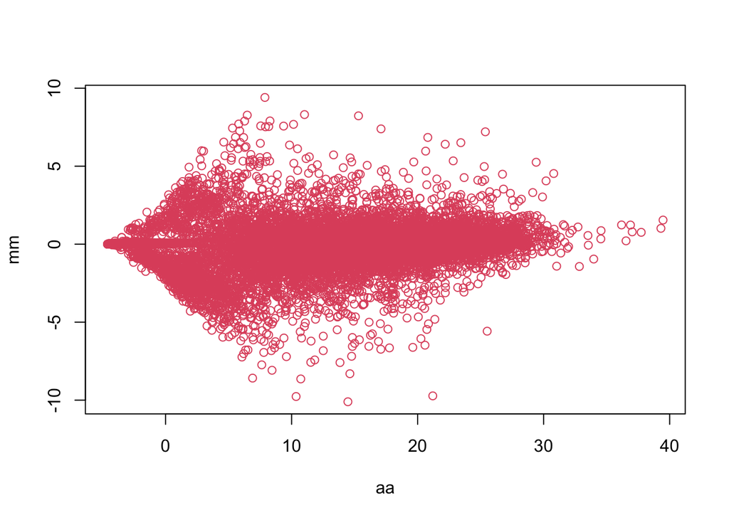

```r
# rlog
rlogged <- rlog(edata)

mm = rlogged[,1] - rlogged[,2]
aa =  rlogged[,1] + rlogged[,2]
plot(aa, mm, col = 2)
```

## Question 9:

```r
con =url("http://bowtie-bio.sourceforge.net/recount/ExpressionSets/montpick_eset.RData")
load(file=con)
close(con)
mp = montpick.eset
pdata=pData(mp)
edata=as.data.frame(exprs(mp))
fdata = fData(mp)
```

Cluster the data

1. With no changes to the data
2. After filtering all genes with rowMeansrowMeans less than 100
3. After taking the log2log2 transform of the data without filtering

Color the samples by which study they came from (Hint: consider using the function myplclust.Rmyplclust.R in the package rafalibrafalib available from CRAN and looking at the argument lab.collab.col.)

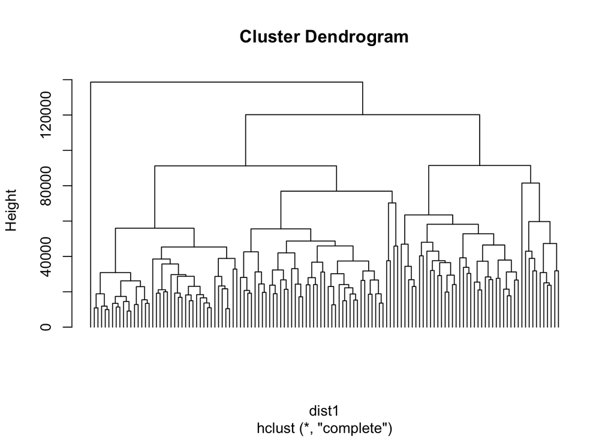

```r
# no changes to the data

nochanges = edata
dist1 = dist(t(nochanges))
colramp = colorRampPalette(c(3, "white", 2))(9)
hclust1 = hclust(dist1)
plot(hclust1, hang = -1, labels = FALSE)
```

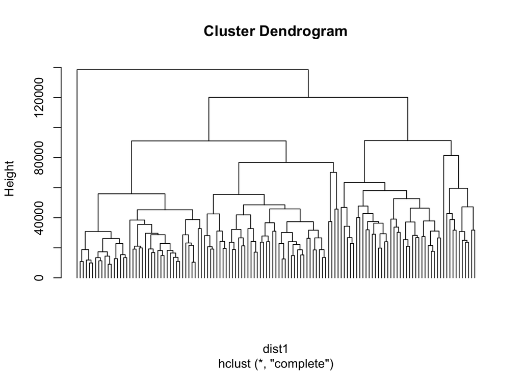

```r
# filtering all genes with rowmeans < 100

low_genes = rowMeans(edata) < 100
filtered = edata[!low_genes,]
dist1 = dist(t(filtered))
hclust1 = hclust(dist1)
plot(hclust1, hang = -1, labels = FALSE)
```

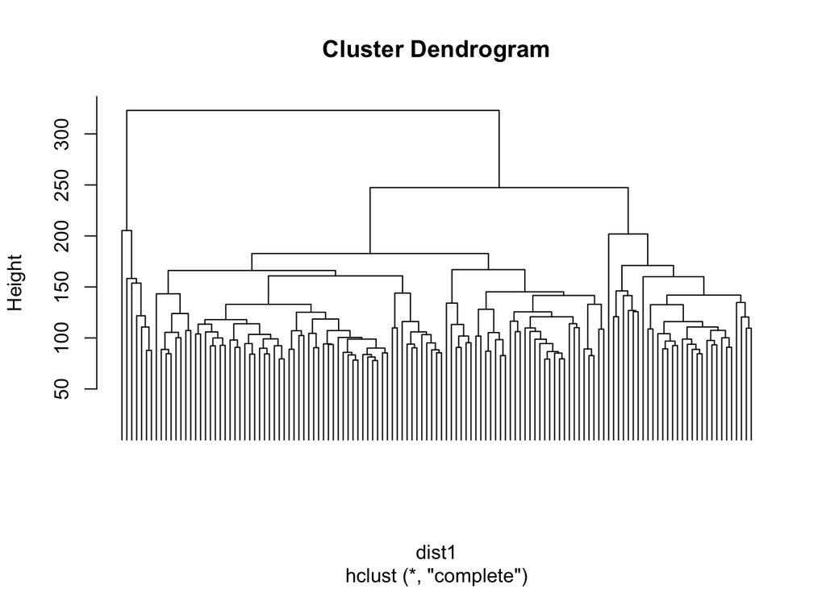

```r
# log2 transform of data
logged = log2(edata + 1)
dist1 = dist(t(logged))
hclust1 = hclust(dist1)
plot(hclust1, hang = -1, labels = FALSE)
```

## Question 10:

```r
con =url("http://bowtie-bio.sourceforge.net/recount/ExpressionSets/montpick_eset.RData")
load(file=con)
close(con)
mp = montpick.eset
pdata=pData(mp)
edata=as.data.frame(exprs(mp))
fdata = fData(mp)
```

- log 2 transform
- k means clustering with set seed
- choose two clusters
- use cutree to cut into two clusters
- compare both things

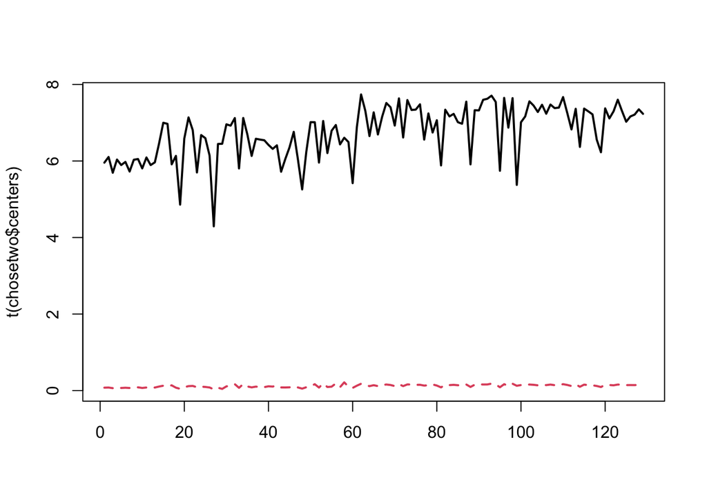

```r
logged = log2(edata + 1)

set.seed(1235)

# choose two clusters
chosetwo = kmeans(logged, centers = 2)
matplot(t(chosetwo$centers), col = 1:2, type = "l", lwd = 2) # 3 centers, 3 colors
```

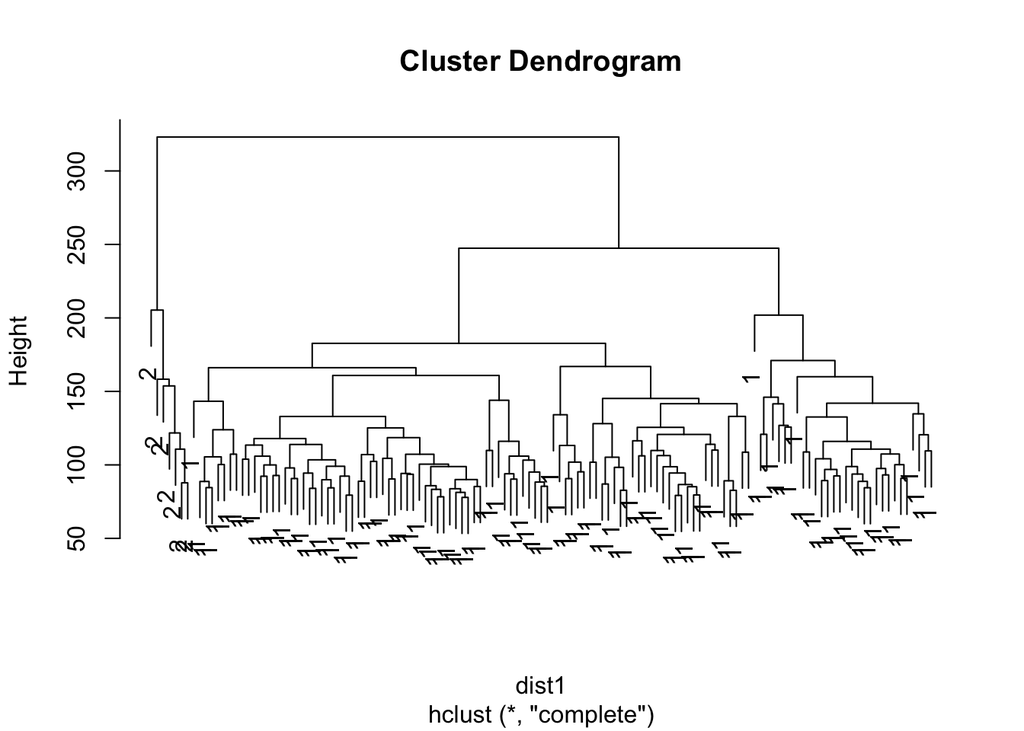

```r
# cluster into two with the hierarchy
dist1 = dist(t(logged))
hclust1 = hclust(dist1)
twotree = cutree(hclust1, 2)
plot(hclust1, twotree)
```

Observations:

- top split is unnatural